# Introduction

## Description of dataset

This dataset contains characteristics of customers of a telecommunications company, such as age, gender, the services they currently use with the company, payment methods and monthly charges, as well as the outcome variable Churn.

The outcome variable Churn, is a binary variable (Yes/No) indicating whether the customer has churned (stopped using the services provided by this telecommunication company). By “learning” the characteristics of the customers who have churned, the company will be able to predict whether their customers are likely to churn, based on historical data, as well as to predict whether a new customer who has such characteristics is likely to stay with the company.

Predicting the outcome makes sense for the telecommunication company since it is in the company’s interest to retain their customers. The developed models could also inform their future strategies when seeking to expand their customer base.

# Preparing the data

## Importing the data

```r
#Import dataset from CSV
df <- read.csv("dataset.csv", head(T))

#Check data formats of each column
str(df)
```

```
## 'data.frame':    7043 obs. of  21 variables:
##  $ customerID      : chr  "7590-VHVEG" "5575-GNVDE" "3668-QPYBK" "7795-CFOCW" ...
##  $ gender          : chr  "Female" "Male" "Male" "Male" ...
##  $ SeniorCitizen   : int  0 0 0 0 0 0 0 0 0 0 ...
##  $ Partner         : chr  "Yes" "No" "No" "No" ...
##  $ Dependents      : chr  "No" "No" "No" "No" ...
##  $ tenure          : int  1 34 2 45 2 8 22 10 28 62 ...
##  $ PhoneService    : chr  "No" "Yes" "Yes" "No" ...
##  $ MultipleLines   : chr  "No phone service" "No" "No" "No phone service" ...
##  $ InternetService : chr  "DSL" "DSL" "DSL" "DSL" ...
##  $ OnlineSecurity  : chr  "No" "Yes" "Yes" "Yes" ...
##  $ OnlineBackup    : chr  "Yes" "No" "Yes" "No" ...
##  $ DeviceProtection: chr  "No" "Yes" "No" "Yes" ...
##  $ TechSupport     : chr  "No" "No" "No" "Yes" ...
##  $ StreamingTV     : chr  "No" "No" "No" "No" ...
##  $ StreamingMovies : chr  "No" "No" "No" "No" ...
##  $ Contract        : chr  "Month-to-month" "One year" "Month-to-month" "One year" ...
##  $ PaperlessBilling: chr  "Yes" "No" "Yes" "No" ...
##  $ PaymentMethod   : chr  "Electronic check" "Mailed check" "Mailed check" "Bank transfer (automatic)" ...
##  $ MonthlyCharges  : num  29.9 57 53.9 42.3 70.7 ...
##  $ TotalCharges    : num  29.9 1889.5 108.2 1840.8 151.7 ...
##  $ Churn           : chr  "No" "No" "Yes" "No" ...
```

## Data clean-up

Several rows are missing values for the `TotalCharges` column. As a result, we decided to omit them from our dataset. There were 11 such observations, as can be seen below.

```r
#Find rows with missing values
df[!complete.cases(df),]
```

```
##      customerID gender SeniorCitizen Partner Dependents tenure PhoneService
## 489  4472-LVYGI Female             0     Yes        Yes      0           No
## 754  3115-CZMZD   Male             0      No        Yes      0          Yes
## 937  5709-LVOEQ Female             0     Yes        Yes      0          Yes
## 1083 4367-NUYAO   Male             0     Yes        Yes      0          Yes
## 1341 1371-DWPAZ Female             0     Yes        Yes      0           No
## 3332 7644-OMVMY   Male             0     Yes        Yes      0          Yes
## 3827 3213-VVOLG   Male             0     Yes        Yes      0          Yes
## 4381 2520-SGTTA Female             0     Yes        Yes      0          Yes
## 5219 2923-ARZLG   Male             0     Yes        Yes      0          Yes
## 6671 4075-WKNIU Female             0     Yes        Yes      0          Yes
## 6755 2775-SEFEE   Male             0      No        Yes      0          Yes
##         MultipleLines InternetService      OnlineSecurity        OnlineBackup
## 489  No phone service             DSL                 Yes                  No
## 754                No              No No internet service No internet service
```

[output cut: 45 more lines]

```r
#Exclude rows with missing values - 11 out of about 7000
df <- na.omit(df)
```

## Convert data formats

Here, we first removed the `customerID` column as we are not interested in these values to make our predictions.

We then separated the different levels of our qualitative predictors (or factors) by selecting all variables with values in the character (char) format. We had one more factor `SeniorCitizen` that was not in the char format, and hence also converted this manually.

```r
#Remove first column since this is a unique identifier for each customer
df <- subset(df,select=-customerID)
#Convert all columns which are formatted as character to factor
df <- df %>%
  mutate_if(is.character,as.factor)
#Convert SeniorCitizen to factor as although this is also a factor, it was coded as integers 0 and 1 in the original dataset.
df$SeniorCitizen <- as.factor(df$SeniorCitizen)

#Verify converted data formats are as expected
str(df)
```

```
## 'data.frame':    7032 obs. of  20 variables:
##  $ gender          : Factor w/ 2 levels "Female","Male": 1 2 2 2 1 1 2 1 1 2 ...
##  $ SeniorCitizen   : Factor w/ 2 levels "0","1": 1 1 1 1 1 1 1 1 1 1 ...
##  $ Partner         : Factor w/ 2 levels "No","Yes": 2 1 1 1 1 1 1 1 2 1 ...
##  $ Dependents      : Factor w/ 2 levels "No","Yes": 1 1 1 1 1 1 2 1 1 2 ...
##  $ tenure          : int  1 34 2 45 2 8 22 10 28 62 ...
##  $ PhoneService    : Factor w/ 2 levels "No","Yes": 1 2 2 1 2 2 2 1 2 2 ...
##  $ MultipleLines   : Factor w/ 3 levels "No","No phone service",..: 2 1 1 2 1 3 3 2 3 1 ...
##  $ InternetService : Factor w/ 3 levels "DSL","Fiber optic",..: 1 1 1 1 2 2 2 1 2 1 ...
##  $ OnlineSecurity  : Factor w/ 3 levels "No","No internet service",..: 1 3 3 3 1 1 1 3 1 3 ...
##  $ OnlineBackup    : Factor w/ 3 levels "No","No internet service",..: 3 1 3 1 1 1 3 1 1 3 ...
##  $ DeviceProtection: Factor w/ 3 levels "No","No internet service",..: 1 3 1 3 1 3 1 1 3 1 ...
##  $ TechSupport     : Factor w/ 3 levels "No","No internet service",..: 1 1 1 3 1 1 1 1 3 1 ...
##  $ StreamingTV     : Factor w/ 3 levels "No","No internet service",..: 1 1 1 1 1 3 3 1 3 1 ...
##  $ StreamingMovies : Factor w/ 3 levels "No","No internet service",..: 1 1 1 1 1 3 1 1 3 1 ...
##  $ Contract        : Factor w/ 3 levels "Month-to-month",..: 1 2 1 2 1 1 1 1 1 2 ...
##  $ PaperlessBilling: Factor w/ 2 levels "No","Yes": 2 1 2 1 2 2 2 1 2 1 ...
##  $ PaymentMethod   : Factor w/ 4 levels "Bank transfer (automatic)",..: 3 4 4 1 3 3 2 4 3 1 ...
##  $ MonthlyCharges  : num  29.9 57 53.9 42.3 70.7 ...
##  $ TotalCharges    : num  29.9 1889.5 108.2 1840.8 151.7 ...
##  $ Churn           : Factor w/ 2 levels "No","Yes": 1 1 2 1 2 2 1 1 2 1 ...
```

## Splitting the dataset

The next step was to split our dataset into our training and test datasets. We used 3/4 of our observations for the training data, and the remaining for the test data.

```r
#Stratified sampling
df_split <- initial_split(df, prop=3/4, strata=Churn)
df_split
```

```
## <Analysis/Assess/Total>
## <5273/1759/7032>
```

```r
df_recipe <- training(df_split) %>%
  recipe(Churn ~ .) %>%
  prep()

df_testing <- df_recipe %>%
  bake(testing(df_split))
df_training <- juice(df_recipe)

#Verify proportion of Churn customer is indeed preserved in both training and testing sets
df_training %>%
  count(Churn) %>%
  mutate(prop = n/sum(n))
```

```
## # A tibble: 2 × 3
##   Churn     n  prop
##   <fct> <int> <dbl>
## 1 No     3872 0.734
## 2 Yes    1401 0.266
```

```r
df_testing %>%
  count(Churn) %>%
  mutate(prop = n/sum(n))
```

```
## # A tibble: 2 × 3
##   Churn     n  prop
##   <fct> <int> <dbl>
## 1 No     1291 0.734
## 2 Yes     468 0.266
```

## Creating the matrix

```r
df_recipe <- training(df_split) %>%
  recipe(Churn ~ .) %>%
  prep()

df_testing <- df_recipe %>%
  bake(testing(df_split))
df_training <- juice(df_recipe)
```

# Baseline - Models 1 & 2: Logistic Regression and Gradient Descent

## Variable Selection

Here, we performed both forward selection (FS) and backward elimination (BE) to try and narrow down the set of predictor variables that we would include in our first two models below (logistic regression and gradient descent). We note that the model generated by both FS and BE algorithms are in agreement, i.e. yielded the same model.

```r
table(df$InternetService)
```

```
##
##         DSL Fiber optic          No
##        2416        3096        1520
```

```r
#Full model
Full <- glm(Churn ~ ., data=df_training, family="binomial")
#Null model
Null <- glm(Churn ~ 1, data=df_training, family="binomial")

#Mask step function from stats instead of tidymodels
step <- stats::step

#Backward elimination
BE <- step(Full, scope=list(lower=Null, upper=Full), direction="backward", trace=F)
summary(BE)
```

```
##
## Call:
## glm(formula = Churn ~ SeniorCitizen + tenure + MultipleLines +
##     InternetService + OnlineSecurity + TechSupport + StreamingTV +
##     StreamingMovies + Contract + PaperlessBilling + PaymentMethod +
##     MonthlyCharges + TotalCharges, family = "binomial", data = df_training)
##
## Deviance Residuals:
##     Min       1Q   Median       3Q      Max
## -1.9489  -0.6756  -0.3027   0.7186   3.3125
##
## Coefficients: (4 not defined because of singularities)
##                                        Estimate Std. Error z value Pr(>|z|)
## (Intercept)                           3.887e-01  5.946e-01   0.654 0.513324
## SeniorCitizen1                        2.717e-01  9.679e-02   2.807 0.005004 **
## tenure                               -5.414e-02  6.913e-03  -7.831 4.86e-15 ***
## MultipleLinesNo phone service         1.390e-01  2.790e-01   0.498 0.618449
## MultipleLinesYes                      3.440e-01  1.093e-01   3.148 0.001646 **
## InternetServiceFiber optic            1.296e+00  3.197e-01   4.055 5.02e-05 ***
## InternetServiceNo                    -1.357e+00  3.644e-01  -3.724 0.000196 ***
## OnlineSecurityNo internet service            NA         NA      NA       NA
## OnlineSecurityYes                    -3.367e-01  1.139e-01  -2.957 0.003110 **
## TechSupportNo internet service               NA         NA      NA       NA
## TechSupportYes                       -3.016e-01  1.186e-01  -2.544 0.010964 *
## StreamingTVNo internet service               NA         NA      NA       NA
## StreamingTVYes                        4.417e-01  1.556e-01   2.838 0.004543 **
## StreamingMoviesNo internet service           NA         NA      NA       NA
## StreamingMoviesYes                    3.770e-01  1.551e-01   2.431 0.015073 *
## ContractOne year                     -6.661e-01  1.243e-01  -5.359 8.37e-08 ***
## ContractTwo year                     -1.147e+00  1.927e-01  -5.953 2.64e-09 ***
## PaperlessBillingYes                   3.124e-01  8.577e-02   3.642 0.000270 ***
## PaymentMethodCredit card (automatic) -1.849e-01  1.312e-01  -1.410 0.158550
## PaymentMethodElectronic check         2.409e-01  1.092e-01   2.206 0.027369 *
## PaymentMethodMailed check            -5.882e-02  1.316e-01  -0.447 0.654860
## MonthlyCharges                       -1.955e-02  1.224e-02  -1.598 0.110113
## TotalCharges                          2.403e-04  7.909e-05   3.039 0.002376 **
## ---
## Signif. codes:  0 '***' 0.001 '**' 0.01 '*' 0.05 '.' 0.1 ' ' 1
##
## (Dispersion parameter for binomial family taken to be 1)
##
##     Null deviance: 6105.4  on 5272  degrees of freedom
## Residual deviance: 4390.0  on 5254  degrees of freedom
## AIC: 4428
##
## Number of Fisher Scoring iterations: 6
```

```r
#Forward selection
FS <- step(Null, scope=list(lower=Null, upper=Full), direction="forward", trace=F)
summary(FS)
```

```
##
## Call:
## glm(formula = Churn ~ Contract + InternetService + tenure + PaymentMethod +
##     OnlineSecurity + MultipleLines + StreamingTV + TechSupport +
##     PaperlessBilling + TotalCharges + SeniorCitizen + StreamingMovies +
##     MonthlyCharges, family = "binomial", data = df_training)
##
## Deviance Residuals:
##     Min       1Q   Median       3Q      Max
## -1.9489  -0.6756  -0.3027   0.7186   3.3125
##
## Coefficients: (4 not defined because of singularities)
##                                        Estimate Std. Error z value Pr(>|z|)
## (Intercept)                           3.887e-01  5.946e-01   0.654 0.513324
## ContractOne year                     -6.661e-01  1.243e-01  -5.359 8.37e-08 ***
## ContractTwo year                     -1.147e+00  1.927e-01  -5.953 2.64e-09 ***
## InternetServiceFiber optic            1.296e+00  3.197e-01   4.055 5.02e-05 ***
## InternetServiceNo                    -1.357e+00  3.644e-01  -3.724 0.000196 ***
## tenure                               -5.414e-02  6.913e-03  -7.831 4.86e-15 ***
## PaymentMethodCredit card (automatic) -1.849e-01  1.312e-01  -1.410 0.158550
## PaymentMethodElectronic check         2.409e-01  1.092e-01   2.206 0.027369 *
## PaymentMethodMailed check            -5.882e-02  1.316e-01  -0.447 0.654860
## OnlineSecurityNo internet service            NA         NA      NA       NA
## OnlineSecurityYes                    -3.367e-01  1.139e-01  -2.957 0.003110 **
## MultipleLinesNo phone service         1.390e-01  2.790e-01   0.498 0.618449
## MultipleLinesYes                      3.440e-01  1.093e-01   3.148 0.001646 **
## StreamingTVNo internet service               NA         NA      NA       NA
## StreamingTVYes                        4.417e-01  1.556e-01   2.838 0.004543 **
## TechSupportNo internet service               NA         NA      NA       NA
## TechSupportYes                       -3.016e-01  1.186e-01  -2.544 0.010964 *
## PaperlessBillingYes                   3.124e-01  8.577e-02   3.642 0.000270 ***
## TotalCharges                          2.403e-04  7.909e-05   3.039 0.002376 **
## SeniorCitizen1                        2.717e-01  9.679e-02   2.807 0.005004 **
## StreamingMoviesNo internet service           NA         NA      NA       NA
## StreamingMoviesYes                    3.770e-01  1.551e-01   2.431 0.015073 *
## MonthlyCharges                       -1.955e-02  1.224e-02  -1.598 0.110113
## ---
## Signif. codes:  0 '***' 0.001 '**' 0.01 '*' 0.05 '.' 0.1 ' ' 1
##
## (Dispersion parameter for binomial family taken to be 1)
##
##     Null deviance: 6105.4  on 5272  degrees of freedom
## Residual deviance: 4390.0  on 5254  degrees of freedom
## AIC: 4428
##
## Number of Fisher Scoring iterations: 6
```

## Logistic regression

For our baseline model, we performed logistic regression.

### Implementation

```r
model_logistic <- logistic_reg(mode="classification") %>%
  set_engine("glm") %>%
  fit(Churn ~ SeniorCitizen+Dependents+tenure+MultipleLines+InternetService+Contract+PaperlessBilling+PaymentMethod, data=df_training)
```

The coefficients from the model suggest that whether a customer uses a fiber optic internet service is the variable that contributes most to the probability of a customer churning.

```r
model_logistic
```

```
## parsnip model object
##
## Fit time:  22ms
##
## Call:  stats::glm(formula = Churn ~ SeniorCitizen + Dependents + tenure +
##     MultipleLines + InternetService + Contract + PaperlessBilling +
##     PaymentMethod, family = stats::binomial, data = data)
##
## Coefficients:
##                          (Intercept)                        SeniorCitizen1
##                             -0.79779                               0.29616
##                        DependentsYes                                tenure
##                             -0.13879                              -0.03539
##        MultipleLinesNo phone service                      MultipleLinesYes
##                              0.52435                               0.32231
##           InternetServiceFiber optic                     InternetServiceNo
##                              1.10042                              -0.70881
##                     ContractOne year                      ContractTwo year
##                             -0.68180                              -1.23199
##                  PaperlessBillingYes  PaymentMethodCredit card (automatic)
##                              0.34991                              -0.19395
##        PaymentMethodElectronic check             PaymentMethodMailed check
##                              0.31960                              -0.03689
##
## Degrees of Freedom: 5272 Total (i.e. Null);  5259 Residual
## Null Deviance:       6105
## Residual Deviance: 4455  AIC: 4483
```

### Analysis

The resulting model had an accuracy rate of approximately 80% on our test data, and as expected testing error is slightly, although not significantly lower than the testing error.

```r
#Training error
model_logistic %>%
  predict(df_training) %>%
  bind_cols(df_training) %>%
  metrics(truth=Churn, estimate=.pred_class)
```

```
## # A tibble: 2 × 3
##   .metric  .estimator .estimate
##   <chr>    <chr>          <dbl>
## 1 accuracy binary         0.804
## 2 kap      binary         0.464
```

```r
#Testing error
model_logistic %>%
  predict(df_testing) %>%
  bind_cols(df_testing) %>%
  metrics(truth=Churn, estimate=.pred_class)
```

```
## # A tibble: 2 × 3
##   .metric  .estimator .estimate
##   <chr>    <chr>          <dbl>
## 1 accuracy binary         0.796
## 2 kap      binary         0.446
```

## Gradient Descent

Next, we performed a gradient descent on the same variables as in logistic regression above.

### Implementation

```r
#Convert the dataframe into matrix - convert factors into dummy variables
#Same predictor variables used here as in logistic regression in previous sections
x <- model.matrix(Churn ~ SeniorCitizen+Dependents+tenure+MultipleLines+InternetService+Contract+PaperlessBilling+PaymentMethod, data=df_training)
y <- ifelse(df_training["Churn"]=="Yes",1,0)

# Loss function of logistic regression
Loss <- function(X,Y,beta){
  -(1/nrow(Y)) * sum((Y)*log((1/(1+exp(-x %*% beta)))) + (1-Y)*log(1-(1/(1+exp(-x %*% beta)))))
}

#Gradient = First derivative with respect to beta of Loss function
Loss_grad <- function(X,Y,beta){
  (1/nrow(Y)) * (t(X) %*% ((1/(1+exp(-x %*% beta))) - Y))
}

#Initialise the algorithm
p <- ncol(x)
start_beta <- rep(0,p) #Starting at the origin
current_loss <- Loss(x,y,start_beta)
start_grad <- Loss_grad(x,y,start_beta)
next_beta <- start_beta - 0.01 * start_grad
current_beta <- next_beta
current_grad <- start_grad
next_loss <- Loss(x,y,current_beta)
steps <- 0 #Counter

# Below, the number of steps was chosen to be 200,000 and the step-size to be 0.01. This was a result of experimentation with various values in a bid to keep computation manageable but also sufficiently accurate when compared to the results obtained from logistic regression.

while (steps<200000){
  next_grad <- Loss_grad(x,y,current_beta)

  # Moving the beta vector in the direction of the current gradient, resulting in a lower loss value. The current gradient value was normalized.
  next_beta <- current_beta - 0.01 * current_grad / sqrt(sum(current_grad^2))
  #Current_beta updated with the newly computed beta that gives a lower loss.
  current_beta <- next_beta

  current_loss <- next_loss
  current_grad <- next_grad
  next_loss <- Loss(x,y,next_beta)
  steps <- steps+1

  #To check progress of algorithm
  if (steps %% 1000 == 0) print(next_loss - current_loss)
  if (steps %% 1000 == 0) print(steps)
}
```

```
## [1] -0.0005391284
## [1] 1000
## [1] 0.0117494
## [1] 2000
## [1] -0.01527907
## [1] 3000
## [1] -0.0004689144
## [1] 4000
## [1] 0.01154412
## [1] 5000
## [1] -0.01494627
## [1] 6000
## [1] -0.0004522403
## [1] 7000
## [1] 0.01145483
```

[output cut: 385 more lines]

```r
#Gradient descent result
print(current_loss)
```

```
## [1] 0.4241
```

```r
print(current_beta)
```

```
##                                             [,1]
## (Intercept)                          -0.79472756
## SeniorCitizen1                        0.29997986
## DependentsYes                        -0.13830925
## tenure                               -0.05076363
## MultipleLinesNo phone service         0.52751350
## MultipleLinesYes                      0.32611409
## InternetServiceFiber optic            1.10521740
## InternetServiceNo                    -0.70604604
## ContractOne year                     -0.69254423
## ContractTwo year                     -1.26921482
## PaperlessBillingYes                   0.35118596
## PaymentMethodCredit card (automatic) -0.19545307
## PaymentMethodElectronic check         0.32145708
## PaymentMethodMailed check            -0.03646714
```

## Analysis

```r
#Training data
x_train <- x
y_train <- y
#Convert log-odds to probability of churn
logodds_train <- x_train %*% current_beta
odds_train <- exp(logodds_train)
prob_train <- odds_train/(1+odds_train)
#Decision threshold (to predict that customer churns) chosen to be 0.5
y_hat_train <- ifelse(prob_train>=0.5, 1, 0)
outcome_train <- cbind(y_train,prob_train,y_hat_train)
outcome_train <- data.frame(outcome_train)
# Rename column headers
colnames(outcome_train) <- c("True Outcome", "Prob of Churn", "Predicted Outcome")
# Sample output
head(outcome_train)
```

```
##   True Outcome Prob of Churn Predicted Outcome
## 1            0    0.58774845                 1
## 2            0    0.03753869                 0
## 3            0    0.38632836                 0
## 4            0    0.21784908                 0
## 5            0    0.01132824                 0
## 6            0    0.00761876                 0
```

```r
#Confusion matrix on training data
caret::confusionMatrix(as.factor(outcome_train$`Predicted Outcome`), as.factor(outcome_train$`True Outcome`))
```

```
## Confusion Matrix and Statistics
##
##           Reference
## Prediction    0    1
##          0 3586  747
##          1  286  654
##
##                Accuracy : 0.8041
##                  95% CI : (0.7931, 0.8147)
##     No Information Rate : 0.7343
##     P-Value [Acc > NIR] : < 2.2e-16
##
##                   Kappa : 0.439
##
##  Mcnemar's Test P-Value : < 2.2e-16
##
##             Sensitivity : 0.9261
##             Specificity : 0.4668
##          Pos Pred Value : 0.8276
##          Neg Pred Value : 0.6957
##              Prevalence : 0.7343
##          Detection Rate : 0.6801
##    Detection Prevalence : 0.8217
##       Balanced Accuracy : 0.6965
##
##        'Positive' Class : 0
##
```

```r
#Test data
x_test <- model.matrix(Churn ~ SeniorCitizen+Dependents+tenure+MultipleLines+InternetService+Contract+PaperlessBilling+PaymentMethod, data=df_testing)
y_test <- ifelse(df_testing["Churn"]=="Yes",1,0)
#Convert log-odds to probability of churn
logodds_test <- x_test %*% current_beta
odds_test <- exp(logodds_test)
prob_test <- odds_test/(1+odds_test)
#Decision threshold chosen to be 0.5
y_hat_test <- ifelse(prob_test>=0.5, 1, 0)
outcome_test <- cbind(y_test,prob_test,y_hat_test)
# Rename column headers
colnames(outcome_test) <- c("True Outcome", "Prob of Churn", "Predicted Outcome")
# Sample output
head(outcome_test)
```

```
##   True Outcome Prob of Churn Predicted Outcome
## 1            0   0.037337584                 0
## 2            1   0.707154834                 1
## 3            0   0.307609815                 0
## 4            0   0.008384704                 0
## 5            0   0.022364553                 0
## 6            0   0.039328467                 0
```

```r
#Confusion matrix on testing data
caret::confusionMatrix(as.factor(outcome_train$`Predicted Outcome`), as.factor(outcome_train$`True Outcome`))
```

```
## Confusion Matrix and Statistics
##
##           Reference
## Prediction    0    1
##          0 3586  747
##          1  286  654
##
##                Accuracy : 0.8041
##                  95% CI : (0.7931, 0.8147)
##     No Information Rate : 0.7343
##     P-Value [Acc > NIR] : < 2.2e-16
##
##                   Kappa : 0.439
##
##  Mcnemar's Test P-Value : < 2.2e-16
##
##             Sensitivity : 0.9261
##             Specificity : 0.4668
##          Pos Pred Value : 0.8276
##          Neg Pred Value : 0.6957
##              Prevalence : 0.7343
##          Detection Rate : 0.6801
##    Detection Prevalence : 0.8217
##       Balanced Accuracy : 0.6965
##
##        'Positive' Class : 0
##
```

### Comparison Between Logistic Regression Model with Gradient Descent

The table below compares the coefficients obtained from both models. Very similar coefficients were obtained. However, we do note that if we let the gradient descent run for more steps, the results will be more accurate.

```r
compare_table <- cbind(tidy(model_logistic)[,2],current_beta)
colnames(compare_table) <- c("Logistic regression", "Gradient descent")
compare_table
```

```
##                                      Logistic regression Gradient descent
## (Intercept)                                  -0.79778772      -0.79472756
## SeniorCitizen1                                0.29616231       0.29997986
## DependentsYes                                -0.13879344      -0.13830925
## tenure                                       -0.03539138      -0.05076363
## MultipleLinesNo phone service                 0.52434710       0.52751350
## MultipleLinesYes                              0.32230955       0.32611409
## InternetServiceFiber optic                    1.10041983       1.10521740
## InternetServiceNo                            -0.70880987      -0.70604604
## ContractOne year                             -0.68179618      -0.69254423
## ContractTwo year                             -1.23198831      -1.26921482
## PaperlessBillingYes                           0.34991099       0.35118596
## PaymentMethodCredit card (automatic)         -0.19395034      -0.19545307
## PaymentMethodElectronic check                 0.31960051       0.32145708
## PaymentMethodMailed check                    -0.03689412      -0.03646714
```

# Relatively Interpretable - Model 3: Decision Tree

Next up, for our interpretable non-baseline model, we used a decision tree. It should be noted that all of the available predictors were available for selection for the tree (unlike with the previous two models).

## Implementation

```r
#Fit the decision tree on training data
model_tree <- decision_tree(mode="classification") %>%
  set_engine("rpart") %>%
  fit(Churn ~ ., data=df_training)
model_tree
```

```
## parsnip model object
##
## Fit time:  92ms
## n= 5273
##
## node), split, n, loss, yval, (yprob)
##       * denotes terminal node
##
##  1) root 5273 1401 No (0.73430685 0.26569315)
##    2) Contract=One year,Two year 2389  166 No (0.93051486 0.06948514) *
##    3) Contract=Month-to-month 2884 1235 No (0.57177531 0.42822469)
##      6) InternetService=DSL,No 1298  364 No (0.71956857 0.28043143) *
##      7) InternetService=Fiber optic 1586  715 Yes (0.45081967 0.54918033)
##       14) tenure>=13.5 867  361 No (0.58362168 0.41637832)
##         28) TotalCharges>=3083.85 391  130 No (0.66751918 0.33248082) *
##         29) TotalCharges< 3083.85 476  231 No (0.51470588 0.48529412)
##           58) PaymentMethod=Bank transfer (automatic),Credit card (automatic),Mailed check 210   81 No (0.61428571 0.38571429) *
##           59) PaymentMethod=Electronic check 266  116 Yes (0.43609023 0.56390977) *
##       15) tenure< 13.5 719  209 Yes (0.29068150 0.70931850) *
```

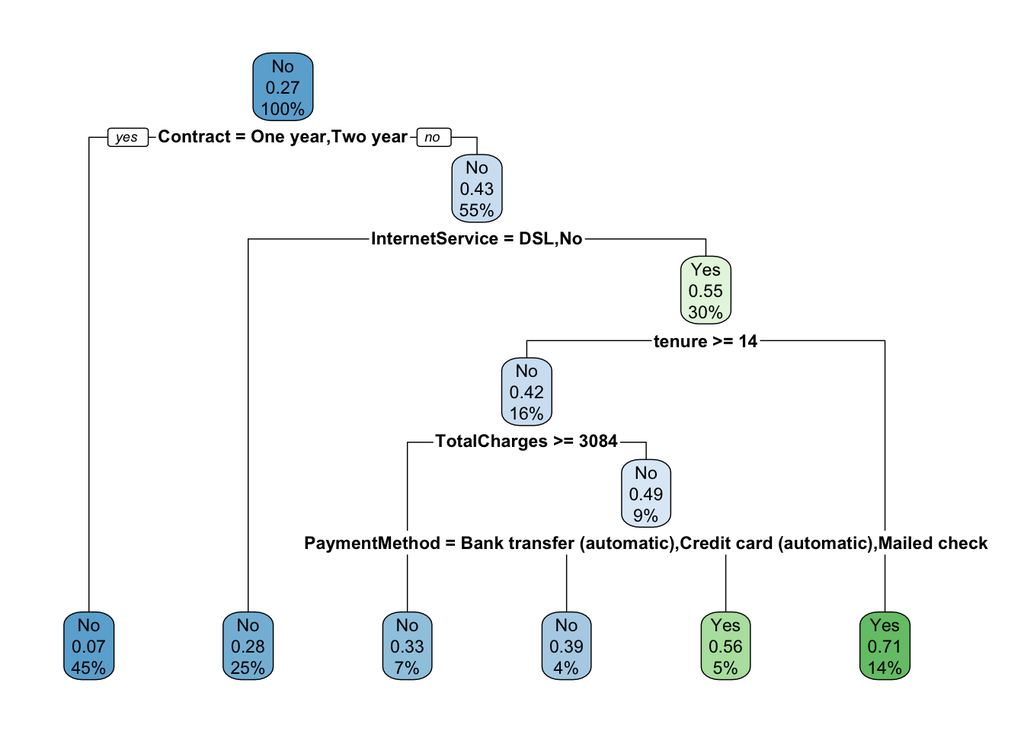

```r
#Plot the decision tree
rpart.plot::rpart.plot(model_tree$fit, roundint = FALSE)
```

## Analysis

```r
#Training error
model_tree %>%
  predict(df_training) %>%
  bind_cols(df_training) %>%
  metrics(truth=Churn, estimate=.pred_class)
```

```
## # A tibble: 2 × 3
##   .metric  .estimator .estimate
##   <chr>    <chr>          <dbl>
## 1 accuracy binary         0.798
## 2 kap      binary         0.428
```

```r
#Testing error
model_tree %>%
  predict(df_testing) %>%
  bind_cols(df_testing) %>%
  metrics(truth=Churn, estimate=.pred_class)
```

```
## # A tibble: 2 × 3
##   .metric  .estimator .estimate
##   <chr>    <chr>          <dbl>
## 1 accuracy binary         0.790
## 2 kap      binary         0.408
```

## Interpretation and Comparison with Baseline

### First-layer node: Contract

The tree predicts that customers on a contract (either one-year or two-year one) will not churn. This is consistent with what is suggested by the previous models. For example, with our logistic regression model, if we ignore all other predictors, we can compute that a customer on a one year contract compared to one not on any contract has a lower churn probability by approximately 16%. Similarly, a customer on a two year contract is about 27% less likely to churn than one not on a contract. This also aligns with the real-life idea that customers not on a contract are less committed to the services they use and hence are more likely to churn.
$$\mathbb{P}(\text{Churn} \, | \, \text{No Contract}) = \frac{e^{0}}{1+e^{0}}=0.5$$
$$\mathbb{P}(\text{Churn} \, | \, \text{One Year Contract}) = \frac{e^{-0.6818}}{1+e^{-0.6818}}=0.3359$$
$$\mathbb{P}(\text{Churn} \, | \, \text{Two Year Contract}) = \frac{e^{-1.2320}}{1+e^{-1.2320}}=0.2258$$

### Second-layer node: Internet Service

Secondly, we observe that customers using a fibre optic internet service are more likely to churn than those using DSL or no internet service, in agreement to the logistic regression model above (calculations shown below). In the tree, we predict that customers who are not on a contract and uses fibre optic internet to Churn, with probability 0.55, which is significantly lower than the probability predicted by the logistic regression model. On the other hand, customers who are not on a contract and do not use fibre optic internet (so either has DSL internet or no internet at all) are predicted to not churn (probability 0.28). This could suggest customer dissatisfaction with the company’s fibre optic offering. Consequently, the company may want to investigate into this further and consider actions they can take to keep these customers.

$$\mathbb{P}(\text{Churn} \, | \, \text{DSL Internet & No Contract}) = \frac{e^{0+0}}{1+e^{0+0}}=0.5$$
$$\mathbb{P}(\text{Churn} \, | \, \text{Fiber Optic Internet & No Contract}) = \frac{e^{1.1004}}{1+e^{1.1004}}=0.7503$$
$$\mathbb{P}(\text{Churn} \, | \, \text{No Internet & No Contract}) = \frac{e^{-0.7088}}{1+e^{-0.7088}}=0.3299$$

### Third-layer node: Tenure

$$\mathbb{P}(\text{Churn} \, | \, \text{Fiber Optic Internet & No Contract & Tenure} = 13) = \frac{e^{0+1.1004+13 \times -0.0354}}{1+e^{0+1.1004+13 \times -0.0354}}=0.6548$$
$$\mathbb{P}(\text{Churn} \, | \, \text{Fiber Optic Internet & No Contract & Tenure} = 14) = \frac{e^{0+1.1004+14 \times -0.0354}}{1+e^{0+1.1004+14 \times -0.0354}}=0.6468$$
$$\mathbb{P}(\text{Churn} \, | \, \text{Fiber Optic Internet & No Contract & Tenure} = 15) = \frac{e^{0+1.1004+15 \times -0.0354}}{1+e^{0+1.1004+15 \times -0.0354}}=0.6386$$

### Lower-layer node: Payment Method

Those using an electronic check (instead of the other payment methods) were more likely to churn (56% verses 39%), given that the customer did not have a contract, use fibre optic internet, had a tenure of at least 14 months, and total charges less than 3084). Indeed, this matched with what the baseline model (logistic regression) suggested: ignoring all other predictors, a customer with an electronic check had the highest churn probability (58%) out of all four payment methods.

$$\mathbb{P}(\text{Churn} \, | \, \text{Electronic Check}) = \frac{e^{0.3196}}{1+e^{0.3196}}=0.5792$$
$$\mathbb{P}(\text{Churn} \, | \, \text{Mailed Check}) = \frac{e^{-0.0369}}{1+e^{-0.0369}}=0.4908$$
$$\mathbb{P}(\text{Churn} \, | \, \text{Credit Card}) = \frac{e^{-0.1940}}{1+e^{-0.1940}}=0.4517$$
$$\mathbb{P}(\text{Churn} \, | \, \text{Bank Transfer}) = \frac{e^{0}}{1+e^{0}}=0.5$$